# Bellabeat

## Share

### Creating Color and Size Variables for Aesthetics

```r
color = 'darkblue'
size = 1.5
```

### Positive Correlation between Total Daily Steps and Calories Burned

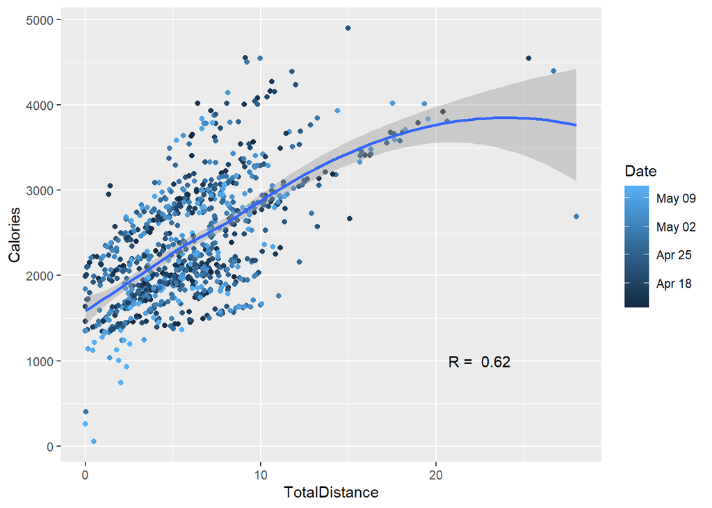

```r
# Exclude days when total steps were equal to zero
daily_activity = filter(daily_activity, TotalDistance !=0)

# Find correlation between two variables & round
R_1 = cor(daily_activity$TotalDistance, daily_activity$Calories)
R_1 = round(R_1, digits = 2)

# Plot graph
ggplot(data = daily_activity, mapping = aes(x = TotalDistance, y = Calories, color = Date)) + geom_point(size = size) + geom_smooth() + annotate('text', x = 22.5, y = 1000, label = paste('R = ', R_1))
```

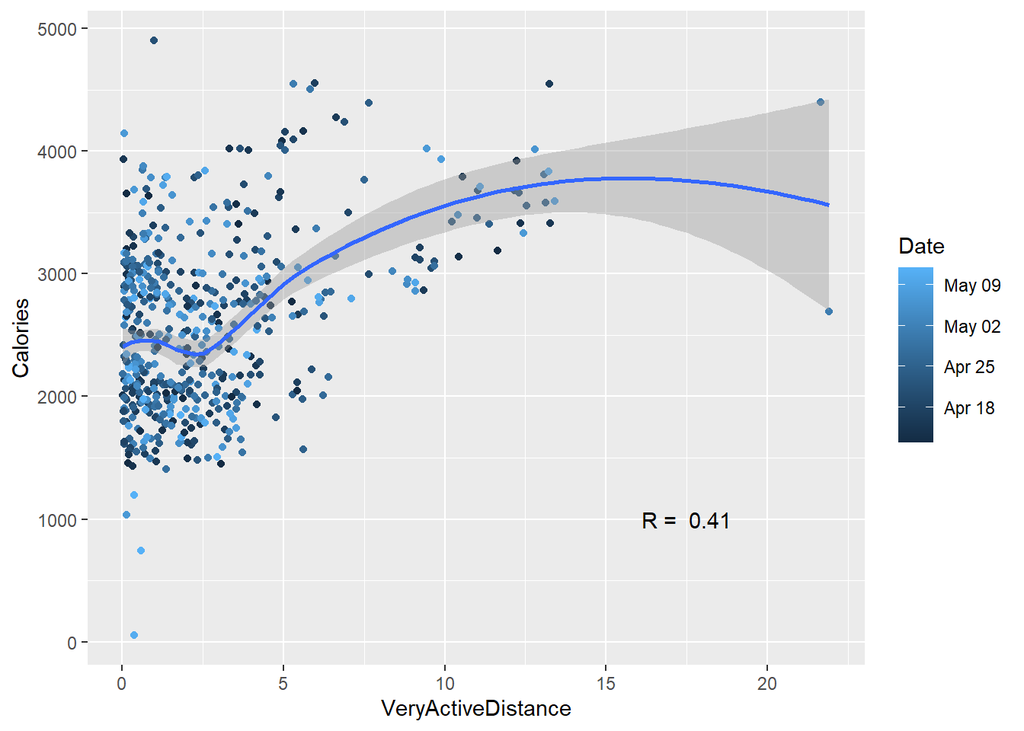

```r
# Exclude days where Total Distance was equal to 0
daily_activity = filter(daily_activity, VeryActiveDistance != 0)

# Find correlation between two variables and round
R_2 = cor(daily_activity$VeryActiveDistance, daily_activity$Calories)
R_2 = round(R_2, digits = 2)


# Plot Graph
ggplot(data = daily_activity, mapping = aes(x = VeryActiveDistance, y = Calories, color = Date)) + geom_point(size = size) + geom_smooth() + annotate('text', x = 17.5, y = 1000, label = paste('R = ', R_2))
```

### Correlation Between Total Minutes Asleep and Calories

This graph is to find correlation between Total Minutes Asleep and Calories burned. Our correlation coefficient is 0.13 which tells us there is no relationship between the variables.

```r
  merged_activity_sleep = inner_join(daily_activity, daily_sleep, by=c('Id','Date'))

# Exclude days when Total Minutes Asleep was 0
#merged_activity_sleep = filter(merged_activity_sleep, TotalMinutesAsleep != 0)

# Find correlation between two variables and round
R_3 = cor(merged_activity_sleep$TotalMinutesAsleep, merged_activity_sleep$Calories)
R_3 = round(R_3, digits = 2)
R_3
```

```
## [1] 0.13
```

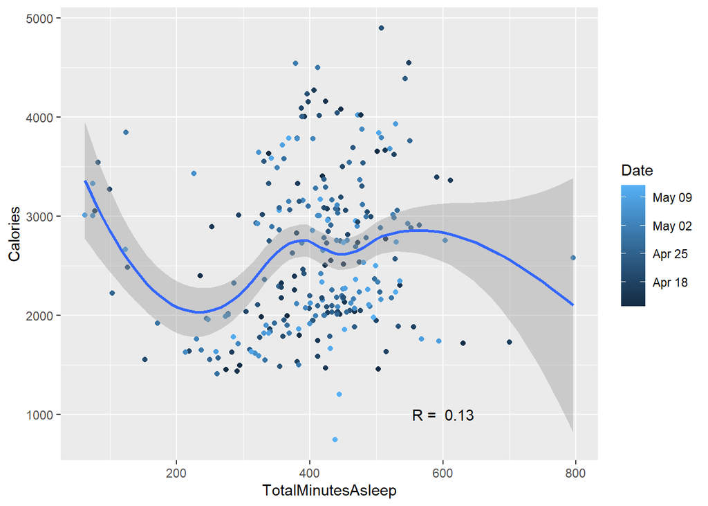

```r
# Plot Graph
ggplot(data = merged_activity_sleep, mapping = aes(x = TotalMinutesAsleep, y = Calories, color = Date)) + geom_point(size = size) + geom_smooth() + annotate('text', x = 600, y = 1000, label = paste('R = ', R_3))
```

### Total Time Asleep vs Total Time in Bed

Here we tested the correlation between Total Time Asleep with Total Time in Bed. Our correlation coefficient is 0.93 which tells us the longer someone spends in bed the longer they will sleep. This is useful to know for our users that would like to get more sleep.

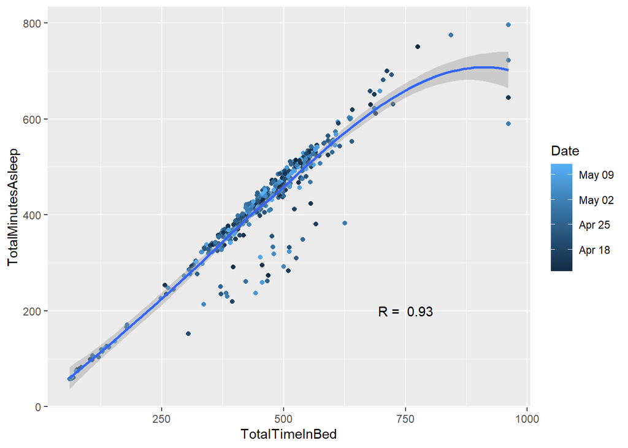

```r
R_4 = cor(daily_sleep$TotalMinutesAsleep, daily_sleep$TotalTimeInBed)
R_4 = round(R_4, digits = 2)

ggplot(data = daily_sleep, mapping = aes(x = TotalTimeInBed, y = TotalMinutesAsleep, color = Date)) + geom_point() +geom_smooth() + annotate('text', x = 750, y = 200, label = paste('R = ', R_4))
```

## TotalTimeInBed and TotalMinutesAsleep throughout the Week

Here we tested to see which days of the week users got the most and the least sleep to see if any trends emerged. Sunday, on average, users got the most sleep with every other day being quite consistent. There is an unexplained peak in sleep time on Wednesday.

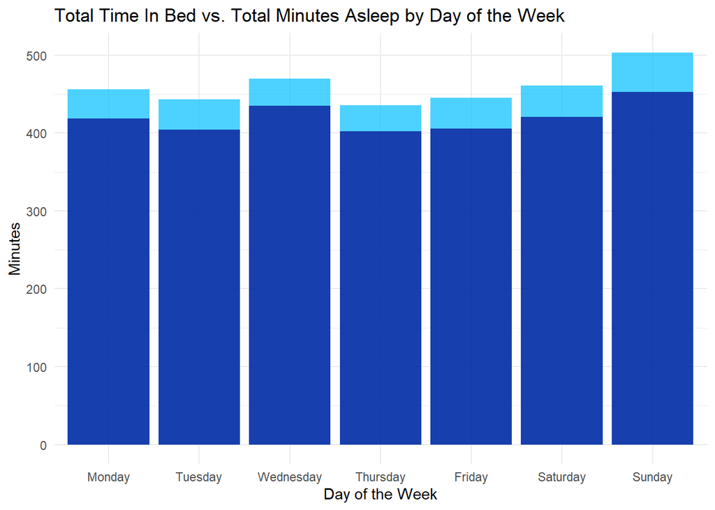

```r
day_order <- c("Monday", "Tuesday", "Wednesday", "Thursday", "Friday", "Saturday", "Sunday")

daily_sleep_week <- daily_sleep %>%
  mutate(DayOfWeek = weekdays(Date)) %>%
  group_by(DayOfWeek) %>%
  summarise(TotalTimeInBed = mean(TotalTimeInBed),
            TotalMinutesAsleep = mean(TotalMinutesAsleep))

daily_sleep_week$DayOfWeek <- factor(daily_sleep_week$DayOfWeek, levels = day_order)

# Plot the stacked bar plot
ggplot(daily_sleep_week, aes(x = DayOfWeek)) +
  geom_bar(aes(y = TotalTimeInBed), stat = "identity", fill = "deepskyblue", alpha = 0.7) +
  geom_bar(aes(y = TotalMinutesAsleep), stat = "identity", fill = "darkblue", alpha = 0.7) +
  labs(x = "Day of the Week", y = "Minutes", title = "Total Time In Bed vs. Total Minutes Asleep by Day of the Week",
       fill = "Activity Type") +
  theme_minimal()
```

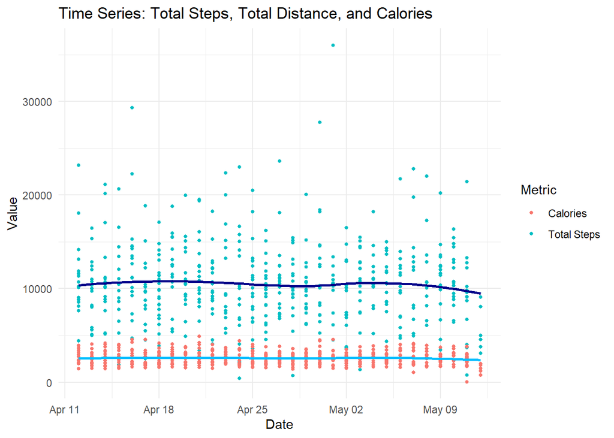

```r
# Plot Time Series for TotalSteps, TotalDistance, and Calories
ggplot(daily_activity, aes(x = Date)) +
  geom_point(aes(y = TotalSteps, color = "Total Steps"), size = 1) +
  geom_point(aes(y = Calories, color = "Calories"), size = 1) +
  geom_smooth(aes(y = TotalSteps), method = "loess", color = color, se = FALSE) +
  geom_smooth(aes(y = Calories), method = "loess", color = 'deepskyblue', se = FALSE) +
  labs(x = "Date", y = "Value", title = "Time Series: Total Steps, Total Distance, and Calories",
       color = "Metric") +
  scale_x_date(date_labels = "%b %d", date_breaks = "1 week") +
  theme_minimal()
```